# Networks_analysis

Kaitlyn Lee

03-07-2023

# Load packages and data

```r
# clear R environment
# rm(list = ls())

library(pacman)
p_load(tidyverse, ggpubr, dplyr, stringr, readxl, pdftools, tm, writexl, pdfsearch, quanteda, NLP, wordcloud, wordcloud2, RColorBrewer, stargazer, texreg, weights, tidytext)

# load in partnering orgs
partner <- read.csv("Data/Partnering_Orgs.csv")
partner$partnering <- 1

# load in non-partnering orgs
non_partner <- read.csv("Data/NonPartnering_Orgs.csv")
non_partner$partnering <- 0

# combine partner + non_partner
all_orgs <- rbind(partner, non_partner)

# load in mission statements
mission_statements <- read.csv("Data/MS_Full.csv")
mission_statements$mentity <- mission_statements$mngentity

# keep only non-duplicates in mission_statements (looks like there is one mentity duplicate here)
mission_statements <- mission_statements[!duplicated(mission_statements$mentity), ]

# merge mission statements
ms <- merge(mission_statements, all_orgs, by="mentity") # should be 1144 obs.

ms <- ms %>% filter(X.Mission.Statement..!="") # keep only orgs with stated mission statements
```

# Pull weights from excel sheets

```r
# Load in total area protected (partnering and non-partnering)
area <- read_excel('Data/CA_orgs_unit_area.xlsx')

area <- area %>% group_by(mngentity) %>% summarise(tot_area=sum(acres_total))

ms <- merge(ms, area, by="mngentity")

area <- data.frame(mngentity = ms$mngentity, tot_area = ms$tot_area, partnering = ms$partnering)

# Pull n PAs
n <- read_excel('Data/CA_orgs_nUnits.xlsx')

vars_keep <- c("mngentity", "units")
n <- n[,(names(n) %in% vars_keep)] # keep only needed vars

area <- merge(area, n, by="mngentity")

area <- area %>% filter(mngentity %in% ms$mentity) # keep only orgs with stated mission statements
```

# Pull themes

```r
# Load and clean Emily's themes
themes <- read_excel('Themes_KeyPhrases_final.xlsx')
keep <- 2:21
themes = themes[keep,] #keep only 2-24

ecology_theme <- themes$`Ecology/Consvervation`
social_theme <- themes$Socioeconomic[1:19]
social_theme <- c(social_theme, "recreat opportun")
```

# Text mining - all phrases

```r
ms$X.Mission.Statement.. <- str_remove_all(ms$X.Mission.Statement.., "<")
ms$X.Mission.Statement.. <- str_remove_all(ms$X.Mission.Statement.., ">")
ms$X.Mission.Statement.. <- str_remove_all(ms$X.Mission.Statement.., "[[:punct:]]")
ms$X.Mission.Statement.. <-  str_replace_all(ms$X.Mission.Statement.., "[^[:alnum:]]", " ")

# Create a corpus
docs <- data.frame(doc_id = ms$mngentity,
                   text = ms$X.Mission.Statement..,
                   stringsAsFactors = FALSE)
docs <- VCorpus(DataframeSource(docs))

# clean text
docs <- docs %>%
  tm_map(removeNumbers) %>%
  tm_map(removePunctuation) %>%
  tm_map(stripWhitespace) %>%
  tm_map(stemDocument)
docs <- tm_map(docs, content_transformer(tolower))
docs <- tm_map(docs, removeWords, stopwords("english"))

BigramTokenizer <-
  function(x)
    unlist(lapply(ngrams(words(x), 2), paste, collapse = " "), use.names = FALSE)

dtm <- DocumentTermMatrix(docs, control=list(tokenize=BigramTokenizer))
matrix <- as.matrix(dtm)
words <- sort(colSums(matrix), decreasing=TRUE)
df <- data.frame(word = names(words),freq=words)

phrases <- tidy(dtm)

phrases <- phrases %>% rename(mngentity = document, freq=count, pattern=term)

phrases <- merge(phrases, area, by="mngentity")
phrases_freq <- phrases

# generate categorical var to use for chi-sq
duptimes <- phrases$freq

idx <- rep(1:nrow(phrases), duptimes)

phrases <- phrases[idx,]

vars_drop <- c("freq")
phrases <- phrases[,!(names(phrases) %in% vars_drop)] # keep only needed vars
```

# Create data subsets for the two themes - include observations for orgs. with 0 frequency

```r
##### Ecology theme #####
phrases_ecology <- phrases_freq
phrases_ecology <- phrases_ecology %>% filter(phrases_ecology$pattern %in% ecology_theme)

# calculate average freq for ALL WORDS in the theme for partnering and non-partnering by mngentity
phrases_ecology <- phrases_ecology %>% group_by(mngentity, partnering, tot_area, units) %>% summarise(freq = sum(freq))

phrases_ecology$freq <- as.double(phrases_ecology$freq)

# add freq of 0 for orgs that do not use these
no_ecology <- area[which(!area$mngentity %in% phrases_ecology$mngentity),]
no_ecology$freq <- 0
no_ecology$freq <- as.double(no_ecology$freq)

phrases_ecology <- rbind(phrases_ecology, no_ecology)

##### Social theme #####
phrases_social <- phrases_freq
phrases_social <- phrases_social %>% filter(phrases_social$pattern %in% social_theme)

# calculate average freq for ALL WORDS in the theme for partnering and non-partnering by mngentity
phrases_social <- phrases_social %>% group_by(mngentity, partnering, tot_area, units) %>% summarise(freq = sum(freq))

phrases_social$freq <- as.double(phrases_social$freq)

# add freq of 0 for orgs that do not use these
no_social <- area[which(!area$mngentity %in% phrases_social$mngentity),]
no_social$freq <- 0
no_social$freq <- as.double(no_social$freq)

phrases_social <- rbind(phrases_social, no_social)


# Remove FED and PVT orgs
# phrases_ecology <- phrases_ecology %>% filter(!str_detect(mngentity, "FED"))
# phrases_social <- phrases_social %>% filter(!str_detect(mngentity, "FED"))
#
# phrases_ecology <- phrases_ecology %>% filter(!str_detect(mngentity, "PVT"))
# phrases_social <- phrases_social %>% filter(!str_detect(mngentity, "PVT"))
```

# Chi-square: all partner vs. all non-partner all key phrase frequency

- Hypoth test 1: do phrase/word frequencies differ between partnering and non-partnering
- All phrases frequency chi squared
- Key result - partnering and non-partnering orgs use phrases with different frequencies, this is statistically significant at the 1% level. This result is robust to both weighting schemes.

```r
###### phrases - all #####
# unweighted
phrases_unwtd_partner_nonpartner <- chisq.test(phrases$pattern, phrases$partnering)
# phrases_unwtd_partner_nonpartner

# tot area weighted
phrases_totarea_wtd_partner_nonpartner <- wtd.chi.sq(phrases$pattern, phrases$partnering, weight=phrases$tot_area)
# phrases_totarea_wtd_partner_nonpartner

# N PAs weighted
phrases_NPAs_wtd_partner_nonpartner <- wtd.chi.sq(phrases$pattern, phrases$partnering, weight=phrases$units)
# phrases_NPAs_wtd_partner_nonpartner

####### test using contingency table as input #####
phrase_table <- table(phrases$pattern, phrases$partnering)

# unweighted
table_phrases_unwtd_partner_nonpartner <- chisq.test(phrase_table)
# table_phrases_unwtd_partner_nonpartner

# check df should be 1 - # of phrases
# phrases %>% group_by(pattern) %>% summarise()


# Make table
coefficient.names <- c("Chi-square", "Degrees of Freedom", "P-value")
# create the texreg object
    x1 <- createTexreg(coef.names = coefficient.names,
    coef = c(phrases_unwtd_partner_nonpartner$statistic, phrases_unwtd_partner_nonpartner$parameter, phrases_unwtd_partner_nonpartner$p.value))

    x2 <- createTexreg(coef.names = coefficient.names,
    coef = c(phrases_totarea_wtd_partner_nonpartner["Chisq"], phrases_totarea_wtd_partner_nonpartner["df"], phrases_totarea_wtd_partner_nonpartner["p.value"]))

    x3 <- createTexreg(coef.names = coefficient.names,
    coef = c(phrases_NPAs_wtd_partner_nonpartner["Chisq"], phrases_NPAs_wtd_partner_nonpartner["df"], phrases_NPAs_wtd_partner_nonpartner["p.value"]))

htmlreg(list(x1, x2, x3), threeparttable = TRUE, custom.model.names = c("Unweighted", "Weighted by Total Area", "Weighted by N PAs"), caption = "Chi-Square Test for Differences in Common Phrases in Partnering and Non-Partnering Mission Statements", caption.above = TRUE, custom.note = "Note: Chi-Square values, degrees of freedom, and p-values reported.")
```

Chi-Square Test for Differences in Common Phrases in Partnering and Non-Partnering Mission Statements

|  | Unweighted | Weighted by Total Area | Weighted by N PAs |
| --- | --- | --- | --- |
| Chi-square | 9454.04 | 10690.24 | 11291.51 |
| Degrees of Freedom | 8775.00 | 8775.00 | 8775.00 |
| P-value | 0.00 | 0.00 | 0.00 |

Note: Chi-Square values, degrees of freedom, and p-values reported.

# T-test: all partner vs. all non-partner average theme

- phrases associated with themes differ for some themes (conservation) between non p and p
- Ecology theme:
- Key results ecology theme two tailed tests - Partnering and non-partnering orgs use conservation themed words with different freuqencies on avg., unweighted test is stat sig at the 1% level. Weighting by total area is insignificant and weighting by N PAs is stat sig at the 1% level.
- Key results ecology theme one tailed tests - Partnering orgs use conservation themed words more on avg., unweighted test is stat sig at the 1% level. For both weighting schemes the difference in means is stat sig, at the 10% level with area weighted and at the 1% level for N PAs weighted.
- Social theme:
- Key results social theme two tailed tests - Partnering and non-partnering orgs use social themed words with different freuqencies on avg., unweighted test is stat sig at the 1% level. This result is robust to both weighting schemes.
- Key results social theme one tailed tests - Partnering orgs use social themed words less on avg., this is stat sig at the 1% level. The total area weighted test is insignificant and the sign of the difference changes. Weighted by N PAs gives the same result as the unweighted test, partnering orgs use social themed words less on avge and this is stat sig at 1% level.

```r
##### Ecology theme #####
# pull partnering and non partnering groups
partner_ecology <- filter(phrases_ecology, partnering==1)
nonpartner_ecology <- filter(phrases_ecology, partnering==0)

# Conduct t-test for difference in means (two-tailed)
# unweighted
ttest_unwtd_ecology <- t.test(partner_ecology$freq, nonpartner_ecology$freq, alternative = c("two.sided"), mu = 0, conf.level = 0.95)
ttest_unwtd_ecology
```

```
##
##  Welch Two Sample t-test
##
## data:  partner_ecology$freq and nonpartner_ecology$freq
## t = 5.1458, df = 148.77, p-value = 8.291e-07
## alternative hypothesis: true difference in means is not equal to 0
## 95 percent confidence interval:
##  0.3250567 0.7303411
## sample estimates:
## mean of x mean of y
## 0.8596491 0.3319502
```

```r
ttest_unwtd_ecology_greater <- t.test(partner_ecology$freq, nonpartner_ecology$freq, alternative = c("greater"), mu = 0, conf.level = 0.95)
ttest_unwtd_ecology_greater
```

```
##
##  Welch Two Sample t-test
##
## data:  partner_ecology$freq and nonpartner_ecology$freq
## t = 5.1458, df = 148.77, p-value = 4.146e-07
## alternative hypothesis: true difference in means is greater than 0
## 95 percent confidence interval:
##  0.3579626       Inf
## sample estimates:
## mean of x mean of y
## 0.8596491 0.3319502
```

```r
# total area weighted
ttest_wtd_totarea_ecology <- wtd.t.test(partner_ecology$freq, nonpartner_ecology$freq, weight=partner_ecology$tot_area, weighty=nonpartner_ecology$tot_area, alternative = c("two.tailed"))
ttest_wtd_totarea_ecology
```

```
## $test
## [1] "Two Sample Weighted T-Test (Welch)"
##
## $coefficients
##     t.value          df     p.value
##   1.4919490 227.1746682   0.1370999
##
## $additional
## Difference     Mean.x     Mean.y   Std. Err
## 0.12380054 0.79438771 0.67058717 0.08297907
```

```r
ttest_wtd_totarea_ecology_greater <- wtd.t.test(partner_ecology$freq, nonpartner_ecology$freq, weight=partner_ecology$tot_area, weighty=nonpartner_ecology$tot_area, alternative = c("greater"))
ttest_wtd_totarea_ecology_greater
```

```
## $test
## [1] "Two Sample Weighted T-Test (Welch)"
##
## $coefficients
##      t.value           df      p.value
##   1.49194904 227.17466823   0.06854993
##
## $additional
## Difference     Mean.x     Mean.y   Std. Err
## 0.12380054 0.79438771 0.67058717 0.08297907
```

```r
# N PAs weighted
ttest_wtd_units_ecology <- wtd.t.test(partner_ecology$freq, nonpartner_ecology$freq, weight=partner_ecology$units, weighty=nonpartner_ecology$units, alternative = c("two.tailed"))
ttest_wtd_units_ecology
```

```
## $test
## [1] "Two Sample Weighted T-Test (Welch)"
##
## $coefficients
##      t.value           df      p.value
## 7.273551e+00 1.383815e+02 2.362510e-11
##
## $additional
## Difference     Mean.x     Mean.y   Std. Err
##  0.7578281  1.0282710  0.2704428  0.1041896
```

```r
ttest_wtd_units_ecology_greater <- wtd.t.test(partner_ecology$freq, nonpartner_ecology$freq, weight=partner_ecology$units, weighty=nonpartner_ecology$units, alternative = c("greater"))
ttest_wtd_units_ecology_greater
```

```
## $test
## [1] "Two Sample Weighted T-Test (Welch)"
##
## $coefficients
##      t.value           df      p.value
## 7.273551e+00 1.383815e+02 1.181263e-11
##
## $additional
## Difference     Mean.x     Mean.y   Std. Err
##  0.7578281  1.0282710  0.2704428  0.1041896
```

```r
##### Social theme #####
# pull partnering and non partnering groups
partner_social <- filter(phrases_social, partnering==1)
nonpartner_social <- filter(phrases_social, partnering==0)

# Conduct t-test for difference in means (two-tailed)
# unweighted
ttest_unwtd_social <- t.test(partner_social$freq, nonpartner_social$freq, alternative = c("two.sided"), mu = 0, conf.level = 0.95)
ttest_unwtd_social
```

```
##
##  Welch Two Sample t-test
##
## data:  partner_social$freq and nonpartner_social$freq
## t = -5.1802, df = 241.08, p-value = 4.681e-07
## alternative hypothesis: true difference in means is not equal to 0
## 95 percent confidence interval:
##  -0.6899831 -0.3097985
## sample estimates:
## mean of x mean of y
## 0.5789474 1.0788382
```

```r
ttest_unwtd_social_less <- t.test(partner_social$freq, nonpartner_social$freq, alternative = c("less"), mu = 0, conf.level = 0.95)
ttest_unwtd_social_less
```

```
##
##  Welch Two Sample t-test
##
## data:  partner_social$freq and nonpartner_social$freq
## t = -5.1802, df = 241.08, p-value = 2.341e-07
## alternative hypothesis: true difference in means is less than 0
## 95 percent confidence interval:
##        -Inf -0.3405489
## sample estimates:
## mean of x mean of y
## 0.5789474 1.0788382
```

```r
# total area weighted
ttest_wtd_totarea_social <- wtd.t.test(partner_social$freq, nonpartner_social$freq, weight=partner_social$tot_area, weighty=nonpartner_social$tot_area, alternative = c("two.tailed"))
ttest_wtd_totarea_social
```

```
## $test
## [1] "Two Sample Weighted T-Test (Welch)"
##
## $coefficients
##   t.value        df   p.value
##  13.03519 255.80323   0.00000
##
## $additional
## Difference     Mean.x     Mean.y   Std. Err
## 0.88472811 1.71705617 0.83232805 0.06787227
```

```r
ttest_wtd_totarea_social_less <- wtd.t.test(partner_social$freq, nonpartner_social$freq, weight=partner_social$tot_area, weighty=nonpartner_social$tot_area, alternative = c("less"))
ttest_wtd_totarea_social_less
```

```
## $test
## [1] "Two Sample Weighted T-Test (Welch)"
##
## $coefficients
##   t.value        df   p.value
##  13.03519 255.80323   1.00000
##
## $additional
## Difference     Mean.x     Mean.y   Std. Err
## 0.88472811 1.71705617 0.83232805 0.06787227
```

```r
# N PAs weighted
ttest_wtd_units_social <- wtd.t.test(partner_social$freq, nonpartner_social$freq, weight=partner_social$units,weighty=nonpartner_social$units, alternative = c("two.tailed"))
ttest_wtd_units_social
```

```
## $test
## [1] "Two Sample Weighted T-Test (Welch)"
##
## $coefficients
##       t.value            df       p.value
## -5.300777e+00  2.525821e+02  2.515214e-07
##
## $additional
## Difference     Mean.x     Mean.y   Std. Err
## -0.5620687  0.8548211  1.4168898  0.1060351
```

```r
ttest_wtd_units_social_less <- wtd.t.test(partner_social$freq, nonpartner_social$freq, weight=partner_social$units,weighty=nonpartner_social$units, alternative = c("less"))
ttest_wtd_units_social_less
```

```
## $test
## [1] "Two Sample Weighted T-Test (Welch)"
##
## $coefficients
##       t.value            df       p.value
## -5.300777e+00  2.525821e+02  1.257607e-07
##
## $additional
## Difference     Mean.x     Mean.y   Std. Err
## -0.5620687  0.8548211  1.4168898  0.1060351
```

# Chi-square: level composition

- more NGOs in organizations that partner (chi-squared)
- Key result - NGO and non-NGO organizations partner with different frequencies, this is stat sig at the 1% level. This result is robust across both weighting schemes.

```r
# Assign level
area$level <- ""
area$level <- if_else(str_detect(area$mngentity, "NGO"), "NGO", "NON-NGO")


# Chisq test
# unweighted
level_unwtd <- chisq.test(area$level, area$partnering)
# level_unwtd

# tot area weighted
level_totarea_wtd <- wtd.chi.sq(area$level, area$partnering, weight=area$tot_area)
# level_totarea_wtd

# N PAs weighted
level_NPAs_wtd <- wtd.chi.sq(area$level, area$partnering, weight=area$units)
# level_NPAs_wtd

####### test using contingency table as input #####
level_table <- table(area$level, area$partnering)

# unweighted
table_level_unwtd <- chisq.test(level_table)
# table_level_unwtd

# Make table
coefficient.names <- c("Chi-square", "Degrees of Freedom", "P-value")
# create the texreg object
    x1 <- createTexreg(coef.names = coefficient.names,
    coef = c(level_unwtd$statistic, level_unwtd$parameter, level_unwtd$p.value))

    x2 <- createTexreg(coef.names = coefficient.names,
    coef = c(level_totarea_wtd["Chisq"], level_totarea_wtd["df"], level_totarea_wtd["p.value"]))

    x3 <- createTexreg(coef.names = coefficient.names,
    coef = c(level_NPAs_wtd["Chisq"], level_NPAs_wtd["df"], level_NPAs_wtd["p.value"]))

htmlreg(list(x1, x2, x3), threeparttable = TRUE, custom.model.names = c("Unweighted", "Weighted by Total Area", "Weighted by N PAs"), caption = "Chi-Square Test for Frequence of NGOs in Partnering and Non-Partnering Organizations", caption.above = TRUE, custom.note = "Note: Chi-Square values, degrees of freedom, and p-values reported.")
```

Chi-Square Test for Frequence of NGOs in Partnering and Non-Partnering Organizations

|  | Unweighted | Weighted by Total Area | Weighted by N PAs |
| --- | --- | --- | --- |
| Chi-square | 38.73 | 56.20 | 7.31 |
| Degrees of Freedom | 1.00 | 1.00 | 1.00 |
| P-value | 0.00 | 0.00 | 0.01 |

Note: Chi-Square values, degrees of freedom, and p-values reported.

# Main result figure

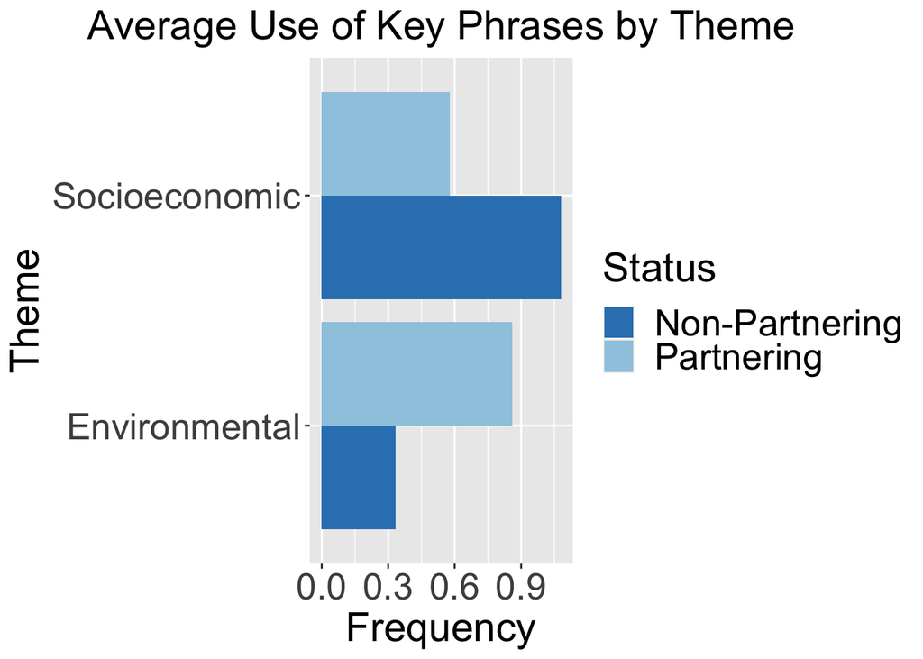

```r
Theme <- c(rep("Environmental" , 2) , rep("Socioeconomic" , 2))
Status <- rep(c("Partnering" , "Non-Partnering") , 2)
Frequency <- c(ttest_unwtd_ecology$estimate['mean of x'], ttest_unwtd_ecology$estimate['mean of y'], ttest_unwtd_social$estimate['mean of x'], ttest_unwtd_social$estimate['mean of y'])
data <- data.frame(Theme,Status,Frequency)

# Plot social agg t test
social_ecology_plot <- ggplot(data, aes(fill=Status, y=Frequency, x=Theme)) +
  scale_fill_manual(values = rev(RColorBrewer::brewer.pal(2,'Blues'))) +
  geom_bar(position="dodge", stat="identity") +
  ggtitle("Average Use of Key Phrases by Theme") +
  theme(plot.title = element_text(size=22,hjust = 0.5),
         axis.text=element_text(size=20),
         axis.title=element_text(size=22), legend.text=element_text(size=20), legend.title=element_text(size=22)) +
  coord_flip()
ggsave(social_ecology_plot, file="Output/Figure_SI3.png", width = 10, height = 5, dpi = 200)
social_ecology_plot
```